# NZ Electricity Generation

covid 19 lockdown v1.0

Ben Anderson, Carsten Dortans and Marilette Lotte

Last run at: 2020-06-10 05:03:12

# 1 About

## 1.1 Citation

If you wish to use any of the material from this report please cite as:

- Ben Anderson, Carsten Dortans and Marilette Lotte (2020) *NZ Electricity Generation: covid 19 lockdown v1.0*, [Centre for Sustainability](http://www.otago.ac.nz/centre-sustainability/), University of Otago: Dunedin.

This work is (c) 2020 the authors. Usage rights are specified in the License section (1.4).

## 1.2 Report circulation

- Public – this report is intended for publication following EECA approval.

## 1.3 Code

All code used to create this report is available from:

- https://github.com/CfSOtago/gridCarbon

## 1.4 License

This work is made available under the Creative Commons [Attribution-ShareAlike 4.0 International (CC BY-SA 4.0) License](https://creativecommons.org/licenses/by-sa/4.0/).

This means you are free to:

- *Share* — copy and redistribute the material in any medium or format
- *Adapt* — remix, transform, and build upon the material for any purpose, even commercially.

Under the following terms:

- *Attribution* — You must give appropriate credit, provide a link to the license, and indicate if changes were made. You may do so in any reasonable manner, but not in any way that suggests the licensor endorses you or your use.
- *ShareAlike* — If you remix, transform, or build upon the material, you must distribute your contributions under the same license as the original.
- *No additional restrictions* — You may not apply legal terms or technological measures that legally restrict others from doing anything the license permits.

**Notices:**

- You do not have to comply with the license for elements of the material in the public domain or where your use is permitted by an applicable exception or limitation.
- No warranties are given. The license may not give you all of the permissions necessary for your intended use. For example, other rights such as publicity, privacy, or moral rights may limit how you use the material.

For the avoidance of doubt and explanation of terms please refer to the full [license notice](https://creativecommons.org/licenses/by-sa/4.0/) and [legal code](https://creativecommons.org/licenses/by-sa/4.0/legalcode).

## 1.5 History

You may not be reading the most recent version of this report. Please check:

- the github [R code repository](https://github.com/CfSOtago/gridCarbon);
- our [issues list](https://github.com/CfSOtago/gridCarbon/issues) for any unfixed problems;
- our [project publictions](https://cfsotago.github.io/gridCarbon/);

We do not ‘support’ the code but if you notice a problem please check the issues on our [repo](https://github.com/CfSOtago/gridCarbon) and if it doesn’t already exist, please open a new one. * this [report’s edit history](https://github.com/CfSOtago/gridCarbon/commits/master/dataAnalysis/)

## 1.6 Support

This work was supported by:

- The [University of Otago](https://www.otago.ac.nz/);
- [SPATIALEC](http://www.energy.soton.ac.uk/tag/spatialec/) - a [Marie Skłodowska-Curie Global Fellowship](http://ec.europa.eu/research/mariecurieactions/about-msca/actions/if/index_en.htm) based at the University of Otago’s [Centre for Sustainability](http://www.otago.ac.nz/centre-sustainability/staff/otago673896.html) (2017-2019) & the University of Southampton’s Sustainable Energy Research Group (2019-2020).
- The European Union via [SPATIALEC](http://www.energy.soton.ac.uk/tag/spatialec/), a Marie Skłodowska-Curie [Global Fellowship](https://ec.europa.eu/research/mariecurieactions/actions/individual-fellowships_en) based at the University of Otago’s [Centre for Sustainability](http://www.otago.ac.nz/centre-sustainability/staff/otago673896.html) (2017-2019) & the University of Southampton’s [Sustainable Energy Research Group](http://www.otago.ac.nz/centre-sustainability/staff/otago673896.html) (2019-2020) (Anderson);
- The Uniersity of Otago via a Centre for Sustainability Summer Scholarship (Lotte) and PhD Studentship (Dortans)

# 2 Introduction

Building on (Khan, Jack, and Stephenson 2018), we are interested in GHG emissions from the NZ electricity generation over time. We are especially interested in how this might change during the NZ covid-19 lockdown period (2020-03-24 to 2020-06-10).

We use two different GHG emissions indicators:

- % of total generation in a halfhour which was ‘low emissions’ where this is defined as wind + solar + hydro
- Calculated CO2e emissions per half hour (not yet implemented)

# 3 Data

## 3.1 Wholesale generation data

Essentially ‘grid’ generation from major power stations of various kinds. Data downloaded from `https://www.emi.ea.govt.nz/Wholesale/Datasets/Generation/Generation_MD/` and pre-processed.

Table 3.1: Grid gen data (first 6 rows)

| Site_Code | POC_Code | Nwk_Code | Gen_Code | Fuel_Code | Tech_Code | Trading_date | Time_Period | kWh | strTime | rTime | rDate | rDateTime | month | year | rDateTimeOrig | rDateTimeNZT | rMonth |
| --- | --- | --- | --- | --- | --- | --- | --- | --- | --- | --- | --- | --- | --- | --- | --- | --- | --- |
| ARA | ARA2201 | MRPL | aratiatia | Hydro | Hydro | 2017-01-01 | TP1 | 11510 | 0:15:00 | 00:15:00 | 2017-01-01 | 2017-01-01 00:15:00 | 1 | 2017 | 2017-01-01T00:15:00Z | 2017-01-01 00:15:00 | Jan |
| ARA | ARA2201 | MRPL | aratiatia | Hydro | Hydro | 2017-01-02 | TP1 | 11570 | 0:15:00 | 00:15:00 | 2017-01-02 | 2017-01-02 00:15:00 | 1 | 2017 | 2017-01-02T00:15:00Z | 2017-01-02 00:15:00 | Jan |
| ARA | ARA2201 | MRPL | aratiatia | Hydro | Hydro | 2017-01-03 | TP1 | 11090 | 0:15:00 | 00:15:00 | 2017-01-03 | 2017-01-03 00:15:00 | 1 | 2017 | 2017-01-03T00:15:00Z | 2017-01-03 00:15:00 | Jan |
| ARA | ARA2201 | MRPL | aratiatia | Hydro | Hydro | 2017-01-04 | TP1 | 13970 | 0:15:00 | 00:15:00 | 2017-01-04 | 2017-01-04 00:15:00 | 1 | 2017 | 2017-01-04T00:15:00Z | 2017-01-04 00:15:00 | Jan |
| ARA | ARA2201 | MRPL | aratiatia | Hydro | Hydro | 2017-01-05 | TP1 | 19680 | 0:15:00 | 00:15:00 | 2017-01-05 | 2017-01-05 00:15:00 | 1 | 2017 | 2017-01-05T00:15:00Z | 2017-01-05 00:15:00 | Jan |
| ARA | ARA2201 | MRPL | aratiatia | Hydro | Hydro | 2017-01-06 | TP1 | 27190 | 0:15:00 | 00:15:00 | 2017-01-06 | 2017-01-06 00:15:00 | 1 | 2017 | 2017-01-06T00:15:00Z | 2017-01-06 00:15:00 | Jan |

## 3.2 Embedded generation data

Essentially ‘non-grid’ generation from solar photovoltaic and small scale wind which is ‘embedded’ - i.e. non-grid connected as it is connected ‘downstream’ of the grid exit points (GXP). Data downloaded from `https://www.emi.ea.govt.nz/Wholesale/Datasets/Metered_data/Embedded_generation` and pre-processed.

Table 3.2: Embedded gen data (first 6 rows)

| POC | NWK_Code | Participant_Code | Loss_Code | Flow_Direction | Trading_date | Time_Period | kWh | strTime | rTime | rDate | rDateTime | month | year | rDateTimeOrig | rDateTimeNZT | rMonth |
| --- | --- | --- | --- | --- | --- | --- | --- | --- | --- | --- | --- | --- | --- | --- | --- | --- |
| ASB0661 | EASH | TRUS | H01 | I | 01/01/2017 | TP1 | 0 | 0:15:00 | 00:15:00 | 2017-01-01 | 2017-01-01 00:15:00 | 1 | 2017 | 2017-01-01T00:15:00Z | 2017-01-01 00:15:00 | Jan |
| ASB0661 | EASH | TRUS | H01 | I | 02/01/2017 | TP1 | 0 | 0:15:00 | 00:15:00 | 2017-01-02 | 2017-01-02 00:15:00 | 1 | 2017 | 2017-01-02T00:15:00Z | 2017-01-02 00:15:00 | Jan |
| ASB0661 | EASH | TRUS | H01 | I | 03/01/2017 | TP1 | 0 | 0:15:00 | 00:15:00 | 2017-01-03 | 2017-01-03 00:15:00 | 1 | 2017 | 2017-01-03T00:15:00Z | 2017-01-03 00:15:00 | Jan |
| ASB0661 | EASH | TRUS | H01 | I | 04/01/2017 | TP1 | 0 | 0:15:00 | 00:15:00 | 2017-01-04 | 2017-01-04 00:15:00 | 1 | 2017 | 2017-01-04T00:15:00Z | 2017-01-04 00:15:00 | Jan |
| ASB0661 | EASH | TRUS | H01 | I | 05/01/2017 | TP1 | 0 | 0:15:00 | 00:15:00 | 2017-01-05 | 2017-01-05 00:15:00 | 1 | 2017 | 2017-01-05T00:15:00Z | 2017-01-05 00:15:00 | Jan |
| ASB0661 | EASH | TRUS | H01 | I | 06/01/2017 | TP1 | 0 | 0:15:00 | 00:15:00 | 2017-01-06 | 2017-01-06 00:15:00 | 1 | 2017 | 2017-01-06T00:15:00Z | 2017-01-06 00:15:00 | Jan |

| year | sumkWh_I | sumkWh_X | nObs_I | nObs_X |
| --- | --- | --- | --- | --- |
| 2017 | 5058591128 | 96830431 | 406372 | 1225680 |
| 2018 | 5069984029 | 121534268 | 527004 | 1577056 |
| 2019 | 4402970047 | 87961803 | 366476 | 1174668 |
| 2020 | 1522565086 | 35504132 | 144624 | 492048 |

Not entirely sure what these codes mean yet. Limited [guidance](https://forum.emi.ea.govt.nz/thread/grid-export-and-embedded-generation-data) available? TBC

> For now embedded generation data is *not* included in the following analysis.

# 4 Analysis (think this section needs some structure/sub-headings!)

In this section we analyse the current developments in electricity generation during the Covid-19 level four alert. The level four alert came into effect on March 25 2020 at 11.59pm as part of the fight agianst the novel Covid-19 virus. The minimum lockdown period is four weeks, ending on April 28 This period has wide-spread implications across New Zealand’s economy and electriicty consumption, amongst other effects such as everyday life in general.

All non-essential busineeses are closed and staff is asked to work from home. This analysis aims to provide insights on developments in electriicty generation. Essential research questions company this research:

- To what extent has electricity generation shown deviation of ‘normal’ generation patterns during the level four alert?
- Has the composition of fuel sources supplying electriicty demand in New Zealand changed during the level four alert?
- Has the level four alert impacted greenhouse-gas emissions associated with electriicty generation?

Table 4.1: Number of observations by fuel

|  | nObs |
| --- | --- |
| Coal | 5808 |
| Diesel | 5808 |
| Gas | 52272 |
| Geo | 63888 |
| Hydro | 220128 |
| Wind | 52272 |

Table 4.2: Example summary data

| Fuel_Code | rDateTimeNZT | Time_Period | rMonth | year | meankWh | sumkWh | nObs | meanMW | sumMW |
| --- | --- | --- | --- | --- | --- | --- | --- | --- | --- |
| Coal | 2018-01-01 00:15:00 | TP1 | Jan | 2018 | 102674 | 102674 | 1 | 205.348 | 205.348 |
| Coal | 2018-01-01 00:45:00 | TP2 | Jan | 2018 | 90091 | 90091 | 1 | 180.182 | 180.182 |
| Coal | 2018-01-01 01:15:00 | TP3 | Jan | 2018 | 85373 | 85373 | 1 | 170.746 | 170.746 |
| Coal | 2018-01-01 01:45:00 | TP4 | Jan | 2018 | 84806 | 84806 | 1 | 169.612 | 169.612 |
| Coal | 2018-01-01 02:15:00 | TP5 | Jan | 2018 | 63093 | 63093 | 1 | 126.186 | 126.186 |
| Coal | 2018-01-01 02:45:00 | TP6 | Jan | 2018 | 54723 | 54723 | 1 | 109.446 | 109.446 |

Table 4.2 shows exemplary data of our data extraction. In addition, Figure 4.1 pictures total generation (this is the sum for each fuel type for all generatinfg plants and all trading periods). Hydro had the highest power output in January and February. Geothermnal was used for base load and an increase in Gas output is viible for the second half of February. Wind intermittently generated while Coal was occasionally integrated. Wood and Diesel did not contribute much in January and February.

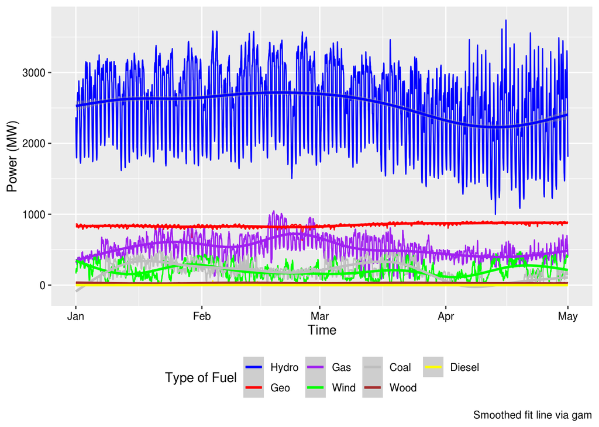

Figure 4.1: Total generation by fuel

Figure 4.2 shows total generation for the first four months of 2020. A red box indicates the alert level four period.

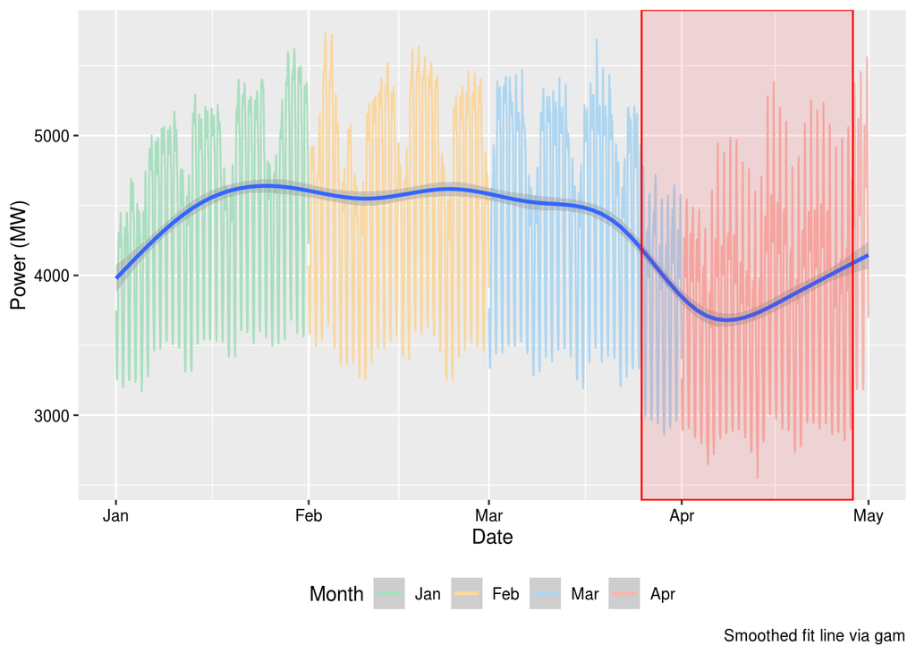

Figure 4.2: Four months of total generation for 2020

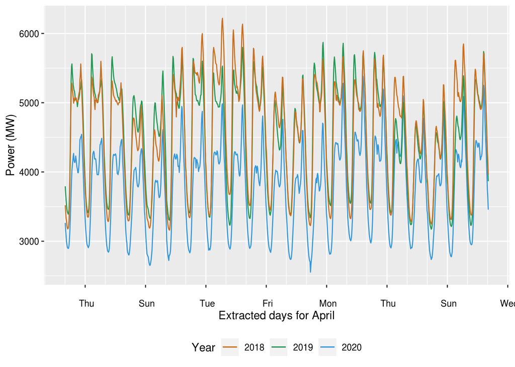

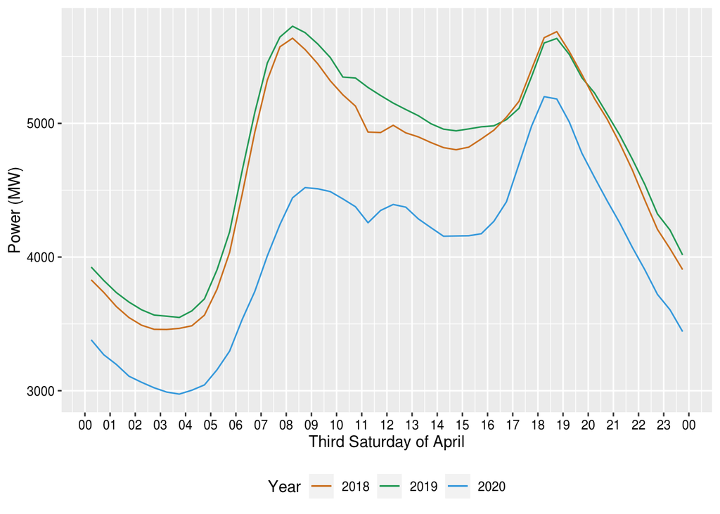

Figure 4.4: Total generation over time for the third Saturday in April by year

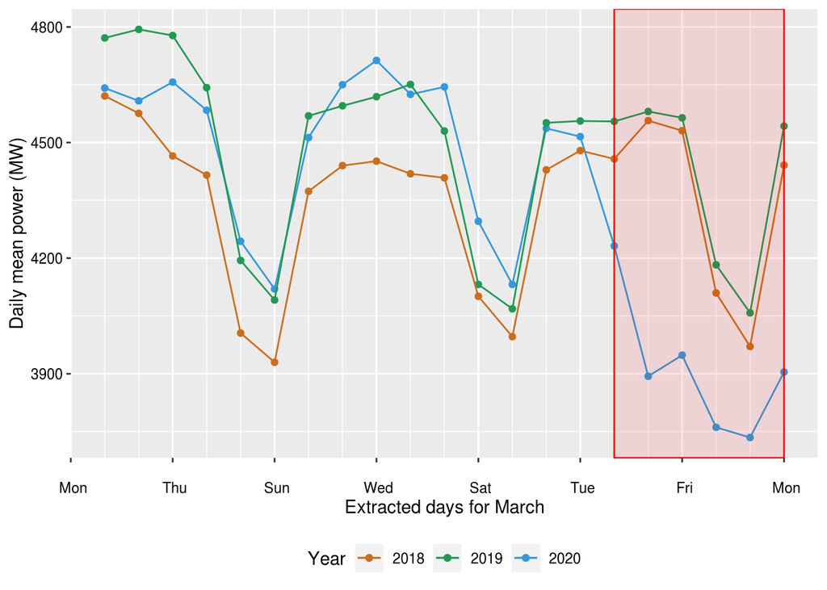

Figure 4.5: Daily mean generation by year for March

A mean over 2018 and 2019 data was compared with 2020 in Figure 4.6. In addition, previous months were considered in this plot as well and show that the variation apparent during the lockdown period is significant between the two reference periods.

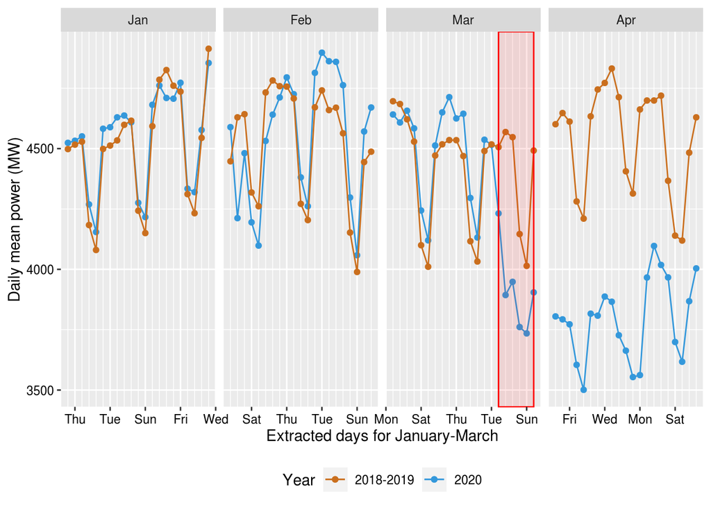

Figure 4.6: Daily mean total generation for 2020 and reference period by month

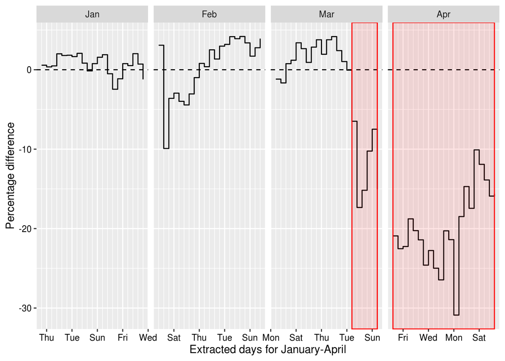

Figure 4.7: Percentage difference in daily mean between 2018-2019 and 2020

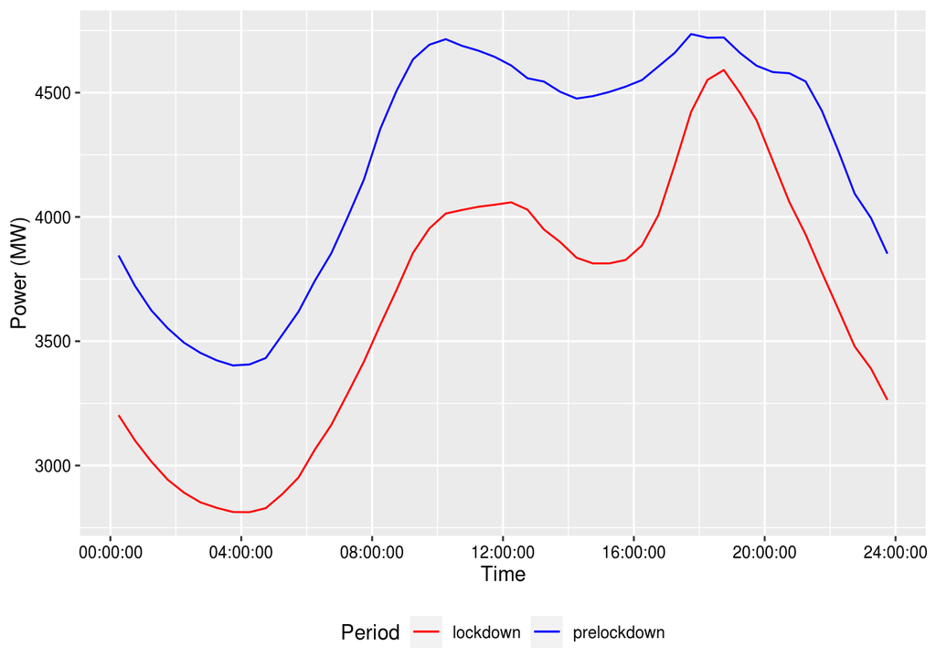

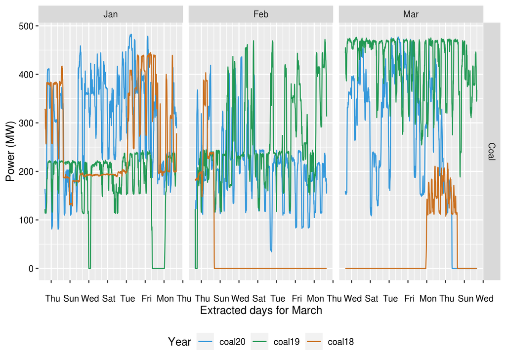

Figure 4.8: Total generation for coal by year and month

# 5 Experiments with openair

[openair](https://davidcarslaw.github.io/openair/) is an R package designed for air quality analysis but it has some useful plots that we can make use of.

> currently fails as openair needs latticeExtra which needs R (≥ 3.6.0)

# 6 Annexes

## 6.1 Wholesale generation data (‘grid’)

Table 6.1: Data summary

| Name | allGridDT |
| --- | --- |
| Number of rows | 4114096 |
| Number of columns | 18 |
| _______________________ |  |
| Column type frequency: |  |
| character | 11 |
| difftime | 1 |
| factor | 1 |
| numeric | 3 |
| POSIXct | 2 |
| ________________________ |  |
| Group variables | None |

**Variable type: character**

| skim_variable | n_missing | complete_rate | min | max | empty | n_unique | whitespace |
| --- | --- | --- | --- | --- | --- | --- | --- |
| Site_Code | 0 | 1 | 3 | 3 | 0 | 61 | 0 |
| POC_Code | 0 | 1 | 7 | 7 | 0 | 61 | 0 |
| Nwk_Code | 0 | 1 | 4 | 4 | 0 | 25 | 0 |
| Gen_Code | 0 | 1 | 3 | 15 | 0 | 63 | 0 |
| Fuel_Code | 0 | 1 | 3 | 6 | 0 | 7 | 0 |
| Tech_Code | 0 | 1 | 3 | 5 | 0 | 5 | 0 |
| Trading_date | 0 | 1 | 10 | 10 | 0 | 1216 | 0 |
| Time_Period | 0 | 1 | 3 | 4 | 0 | 48 | 0 |
| strTime | 0 | 1 | 7 | 8 | 0 | 48 | 0 |
| rDate | 0 | 1 | 10 | 10 | 0 | 1216 | 0 |
| rDateTimeOrig | 0 | 1 | 20 | 20 | 0 | 58356 | 0 |

**Variable type: difftime**

| skim_variable | n_missing | complete_rate | min | max | median | n_unique |
| --- | --- | --- | --- | --- | --- | --- |
| rTime | 0 | 1 | 900 secs | 85500 secs | 43200 secs | 48 |

**Variable type: factor**

| skim_variable | n_missing | complete_rate | ordered | n_unique | top_counts |
| --- | --- | --- | --- | --- | --- |
| rMonth | 0 | 1 | TRUE | 12 | Mar: 419328, Jan: 418128, Apr: 405216, Feb: 380832 |

**Variable type: numeric**

| skim_variable | n_missing | complete_rate | mean | sd | p0 | p25 | p50 | p75 | p100 | hist |
| --- | --- | --- | --- | --- | --- | --- | --- | --- | --- | --- |
| kWh | 0 | 1 | 32809.52 | 48946.96 | 0 | 4617 | 16690 | 42192 | 402430 | ▇▁▁▁▁ |
| month | 0 | 1 | 6.13 | 3.50 | 1 | 3 | 6 | 9 | 12 | ▇▅▅▅▆ |
| year | 0 | 1 | 2018.20 | 0.98 | 2017 | 2017 | 2018 | 2019 | 2020 | ▇▇▁▇▂ |

**Variable type: POSIXct**

| skim_variable | n_missing | complete_rate | min | max | median | n_unique |
| --- | --- | --- | --- | --- | --- | --- |
| rDateTime | 0 | 1 | 2017-01-01 00:15:00 | 2020-04-30 23:45:00 | 2018-09-02 21:45:00 | 58356 |
| rDateTimeNZT | 0 | 1 | 2016-12-31 11:15:00 | 2020-04-30 11:45:00 | 2018-09-02 09:45:00 | 58356 |

## 6.2 Embedded generation data (‘nongrid’)

Table 6.2: Data summary

| Name | allEmbeddedDT |
| --- | --- |
| Number of rows | 5913928 |
| Number of columns | 17 |
| _______________________ |  |
| Column type frequency: |  |
| character | 10 |
| difftime | 1 |
| factor | 1 |
| numeric | 3 |
| POSIXct | 2 |
| ________________________ |  |
| Group variables | None |

**Variable type: character**

| skim_variable | n_missing | complete_rate | min | max | empty | n_unique | whitespace |
| --- | --- | --- | --- | --- | --- | --- | --- |
| POC | 0 | 1 | 7 | 7 | 0 | 21 | 0 |
| NWK_Code | 0 | 1 | 4 | 4 | 0 | 17 | 0 |
| Participant_Code | 0 | 1 | 4 | 4 | 0 | 41 | 0 |
| Loss_Code | 0 | 1 | 3 | 7 | 0 | 23 | 0 |
| Flow_Direction | 0 | 1 | 1 | 1 | 0 | 2 | 0 |
| Trading_date | 0 | 1 | 10 | 10 | 0 | 1157 | 0 |
| Time_Period | 0 | 1 | 3 | 4 | 0 | 48 | 0 |
| strTime | 0 | 1 | 7 | 8 | 0 | 48 | 0 |
| rDate | 0 | 1 | 10 | 10 | 0 | 1157 | 0 |
| rDateTimeOrig | 0 | 1 | 20 | 20 | 0 | 55524 | 0 |

**Variable type: difftime**

| skim_variable | n_missing | complete_rate | min | max | median | n_unique |
| --- | --- | --- | --- | --- | --- | --- |
| rTime | 0 | 1 | 900 secs | 85500 secs | 43200 secs | 48 |

**Variable type: factor**

| skim_variable | n_missing | complete_rate | ordered | n_unique | top_counts |
| --- | --- | --- | --- | --- | --- |
| rMonth | 0 | 1 | TRUE | 12 | Apr: 615552, Mar: 603936, Dec: 494832, Jul: 487008 |

**Variable type: numeric**

| skim_variable | n_missing | complete_rate | mean | sd | p0 | p25 | p50 | p75 | p100 | hist |
| --- | --- | --- | --- | --- | --- | --- | --- | --- | --- | --- |
| kWh | 0 | 1 | 2772.43 | 7240.71 | 0 | 0.02 | 13.52 | 218.98 | 63472.69 | ▇▁▁▁▁ |
| month | 0 | 1 | 6.46 | 3.41 | 1 | 4.00 | 6.00 | 9.00 | 12.00 | ▇▆▅▅▇ |
| year | 0 | 1 | 2018.20 | 0.96 | 2017 | 2017.00 | 2018.00 | 2019.00 | 2020.00 | ▆▇▁▆▂ |

**Variable type: POSIXct**

| skim_variable | n_missing | complete_rate | min | max | median | n_unique |
| --- | --- | --- | --- | --- | --- | --- |
| rDateTime | 0 | 1 | 2017-01-01 00:15:00 | 2020-04-30 23:45:00 | 2018-08-24 17:15:00 | 55524 |
| rDateTimeNZT | 0 | 1 | 2016-12-31 11:15:00 | 2020-04-30 11:45:00 | 2018-08-24 05:15:00 | 55524 |

# 7 Runtime

Analysis completed in 137.71 seconds ( 2.3 minutes) using knitr in [RStudio](http://www.rstudio.com) with R version 3.4.4 (2018-03-15) running on x86_64-pc-linux-gnu.

# 8 R environment

## 8.1 R packages used

- base R (R Core Team 2016)
- bookdown (Xie 2016a)
- data.table (Dowle et al. 2015)
- ggplot2 (Wickham 2009)
- kableExtra (Zhu 2018)
- knitr (Xie 2016b)
- lubridate (Grolemund and Wickham 2011)
- rmarkdown (Allaire et al. 2018)

# References

Allaire, JJ, Yihui Xie, Jonathan McPherson, Javier Luraschi, Kevin Ushey, Aron Atkins, Hadley Wickham, Joe Cheng, and Winston Chang. 2018. *Rmarkdown: Dynamic Documents for R*. https://CRAN.R-project.org/package=rmarkdown.

Carslaw, David C., and Karl Ropkins. 2012. “Openair — an R Package for Air Quality Data Analysis.” *Environmental Modelling & Software* 27–28 (0): 52–61. doi:10.1016/j.envsoft.2011.09.008.

Dowle, M, A Srinivasan, T Short, S Lianoglou with contributions from R Saporta, and E Antonyan. 2015. *Data.table: Extension of Data.frame*. https://CRAN.R-project.org/package=data.table.

Grolemund, Garrett, and Hadley Wickham. 2011. “Dates and Times Made Easy with lubridate.” *Journal of Statistical Software* 40 (3): 1–25. http://www.jstatsoft.org/v40/i03/.

Khan, Imran, Michael W. Jack, and Janet Stephenson. 2018. “Analysis of Greenhouse Gas Emissions in Electricity Systems Using Time-Varying Carbon Intensity.” *Journal of Cleaner Production* 184 (May): 1091–1101. doi:10.1016/j.jclepro.2018.02.309.

R Core Team. 2016. *R: A Language and Environment for Statistical Computing*. Vienna, Austria: R Foundation for Statistical Computing. https://www.R-project.org/.

Wickham, Hadley. 2009. *Ggplot2: Elegant Graphics for Data Analysis*. Springer-Verlag New York. http://ggplot2.org.

Xie, Yihui. 2016a. *Bookdown: Authoring Books and Technical Documents with R Markdown*. Boca Raton, Florida: Chapman; Hall/CRC. https://github.com/rstudio/bookdown.

———. 2016b. *Knitr: A General-Purpose Package for Dynamic Report Generation in R*. https://CRAN.R-project.org/package=knitr.

Zhu, Hao. 2018. *KableExtra: Construct Complex Table with ’Kable’ and Pipe Syntax*. https://CRAN.R-project.org/package=kableExtra.